# Iconicity ratings - substantive analysis

Bodo

11/03/2021

## Introduction

This markdown performs a number of different analysis that serve to demonstrate how the iconicity ratings correlate with other psycholinguistic norms that have been collected. In addition, we produce some plots of the data to give an overview of the ratings.

The models are computed in the file `Bayesian_models.Rmd` and will be loaded in and interpreted here.

## Data and package loading

Load packages:

```r
library(brms, quietly = TRUE)
library(tidyverse, quietly = TRUE)
library(patchwork, quietly = TRUE)
```

For reproducibility:

```r
packageVersion('brms')
```

```
## [1] '2.16.2'
```

```r
packageVersion('tidyverse')
```

```
## [1] '1.3.1'
```

```r
packageVersion('patchwork')
```

```
## [1] '1.1.1'
```

```r
R.Version()$version.string
```

```
## [1] "R version 4.1.1 (2021-08-10)"
```

Load iconicity ratings:

```r
icon <- read.csv('../ratings/iconicity_ratings.csv')
```

```r
# Data for replications:

SER <- read.csv('../additional_data/juhasz_yap_2013_SER.csv',
                stringsAsFactors = FALSE) %>% as_tibble()
AOA <- read.csv('../additional_data/kuperman_2012_AOA.csv',
                stringsAsFactors = FALSE) %>% as_tibble()
lanc <- read.csv('../additional_data/lancaster_sensorimotor_norms_2019.csv',
                stringsAsFactors = FALSE) %>% as_tibble()
SUBTL <- read.csv('../additional_data/brysbaert_2012_SUBTLEX_POS.csv',
                stringsAsFactors = FALSE) %>% as_tibble()
humor <- read.csv('../additional_data/engelthaler_hills_2018_humor.csv',
                stringsAsFactors = FALSE) %>% as_tibble()
ding <- read.csv('../additional_data/dingemanse_thompson_2020.csv',
                stringsAsFactors = FALSE) %>% as_tibble()
```

Rename folders and simplify data frames to include only relevant info. Also make Lancaster norm Word column lowercase. Log10 transform SUBTLEX frequencies and contextual diversity:

```r
# Age-of-acquisition data:

AOA <- AOA %>% select(Word, Rating.Mean) %>%
  rename(AOA = Rating.Mean)

# Sensory experience ratings:

SER <- select(SER, Word, SER)

# Frequency, contextual diversity, and part-of-speech:

SUBTL <- SUBTL %>%
  rename(Freq = FREQcount,
         POS = Dom_PoS_SUBTLEX) %>%
  select(Word, Freq, POS)

# Playfulness:

humor <- select(humor, word, mean) %>%
  rename(humor = mean)

# Dingemanse & Thompson (2020) data:

ding <- select(ding, logletterfreq, word, ico, ico_imputed, ico_imputed_monomorph)
```

Join them into the main iconicity data file:

```r
icon <- left_join(icon, SER, by = c('word' = 'Word'))
icon <- left_join(icon, AOA, by = c('word' = 'Word'))
icon <- left_join(icon, SUBTL, by = c('word' = 'Word'))
icon <- left_join(icon, humor, by = c('word' = 'word'))
icon <- left_join(icon, lanc, by = c('word' = 'Word'))
icon <- left_join(icon, ding, by = c('word' = 'word'))
```

For SUBTLEX, an NA is a true zero:

```r
icon <- mutate(icon,
               Freq = ifelse(is.na(Freq), 0, Freq))
```

Log-transform the frequencies:

```r
icon <- mutate(icon,
               LogFreq = log10(Freq + 1))
```

Z-score all variables:

```r
z_score <- function(x) (x - mean(x, na.rm = TRUE)) / sd(x)

icon <- mutate(icon,
               SER_z = z_score(SER),
               AOA_z = z_score(AOA),
               LogFreq_z = z_score(LogFreq),
               humor_z = z_score(humor),
               logletter_z = z_score(logletterfreq))
```

## Process part of speech tags

Process the part-of-speech information to collapse categories for better representation. First show what categories there are:

```r
sort(table(icon$POS))
```

```
##
##           Ex          Not           To      Article         #N/A Unclassified
##            1            1            1            3            5           10
##  Conjunction   Determiner       Number Interjection      Pronoun  Preposition
##           20           24           34           41           42           52
##         Name       Adverb         Verb    Adjective         Noun
##          182          217         2756         3040         7662
```

Define vector of stuff to set as function words. “Ex” = there. “#N/A” are words like “gonna”, “wanna”.

```r
gram <- c('#N/A', 'Article', 'Conjunction',
          'Determiner', 'Not', 'Number',
          'Preposition', 'Pronoun', 'To',
          'Ex')
```

Set this to function words in a new POS variable:

```r
icon <- mutate(icon,
               POS_simple = ifelse(POS %in% gram, 'Function', POS))
```

Check categories:

```r
table(icon$POS_simple)
```

```
##
##    Adjective       Adverb     Function Interjection         Name         Noun
##         3040          217          183           41          182         7662
## Unclassified         Verb
##           10         2756
```

Get a reduced POS data frame without names and unclassifieds. This will be used later to making computing averages easier.

```r
icon_POS <- filter(icon,
                   !POS_simple %in% c('Unclassified', 'Name'))
```

Check:

```r
table(icon_POS$POS_simple)
```

```
##
##    Adjective       Adverb     Function Interjection         Noun         Verb
##         3040          217          183           41         7662         2756
```

## Check overlap with different datasets for reporting

How many data points?

```r
filter(icon, !is.na(SER)) %>% nrow()
```

```
## [1] 5295
```

```r
filter(icon, !is.na(AOA)) %>% nrow()
```

```
## [1] 13200
```

```r
filter(icon, !is.na(humor)) %>% nrow()
```

```
## [1] 4561
```

## Descriptive statistics

Average iconicity for these:

```r
icon_POS %>% group_by(POS_simple) %>%
  summarize(M = mean(rating),
            SD = sd(rating)) %>%
  arrange(desc(M))
```

```
## # A tibble: 7 × 3
##   POS_simple       M    SD
##   <chr>        <dbl> <dbl>
## 1 Interjection  5.34 1.17
## 2 Verb          3.97 0.953
## 3 Adjective     3.79 0.873
## 4 Noun          3.74 0.853
## 5 <NA>          3.41 0.956
## 6 Adverb        3.35 0.849
## 7 Function      3.20 0.792
```

Count each one for Table 3.

```r
icon_POS %>%
  count(POS_simple)
```

```
##     POS_simple    n
## 1    Adjective 3040
## 2       Adverb  217
## 3     Function  183
## 4 Interjection   41
## 5         Noun 7662
## 6         Verb 2756
## 7         <NA>  591
```

## Correlation table

Get the variables of interest:

```r
these_vars <- c("rating", "SER", "AOA", "LogFreq",
                "logletterfreq", "humor")
```

Get these vars and perform pairwise correlations:

```r
# Get subset:

df_vars <- icon[, these_vars]

# Correlate and round:

all_corrs <- round(cor(df_vars, use = 'complete.obs'), 2)

# Print and save:

all_corrs
```

```
##               rating   SER   AOA LogFreq logletterfreq humor
## rating          1.00  0.16 -0.16   -0.09         -0.25  0.27
## SER             0.16  1.00 -0.26    0.01         -0.02  0.09
## AOA            -0.16 -0.26  1.00   -0.61          0.06  0.09
## LogFreq        -0.09  0.01 -0.61    1.00          0.04 -0.33
## logletterfreq  -0.25 -0.02  0.06    0.04          1.00 -0.25
## humor           0.27  0.09  0.09   -0.33         -0.25  1.00
```

```r
write_csv(as.data.frame(all_corrs), '../tables/all_correlations.csv')
```

## Interpret models

Load all models from the models folder:

```r
all_models <- list.files('../models/')

for (i in seq_along(all_models)) {
  load(str_c('../models/', all_models[i]))
}
```

First, let’s look at all r-squareds:

```r
# FUll model:

bayes_R2(all_mdl)
```

```
##     Estimate  Est.Error      Q2.5     Q97.5
## R2 0.2915376 0.01091212 0.2697078 0.3119847
```

```r
bayes_R2(all_mdl_no_POS)
```

```
##     Estimate Est.Error     Q2.5     Q97.5
## R2 0.2606187 0.0112736 0.238319 0.2823464
```

```r
bayes_R2(noweight_mdl)
```

```
##    Estimate  Est.Error     Q2.5     Q97.5
## R2    0.236 0.01146066 0.213411 0.2582465
```

Next, let’s look at the model summaries:

```r
# FUll model:

all_mdl
```

```
##  Family: gaussian
##   Links: mu = identity; sigma = identity
## Formula: rating | weights(w) ~ 1 + conc_z + SER_z + AOA_z + LogFreq_z + humor_z + POS_simple + logletter_z + ARC_z + SER_z:ARC_z
##    Data: icon_red (Number of observations: 3187)
##   Draws: 4 chains, each with iter = 4000; warmup = 2000; thin = 1;
##          total post-warmup draws = 8000
##
## Population-Level Effects:
##                        Estimate Est.Error l-95% CI u-95% CI Rhat Bulk_ESS
## Intercept                  4.18      0.13     3.92     4.43 1.00     4196
## conc_z                    -0.13      0.02    -0.17    -0.08 1.00     7463
## SER_z                      0.12      0.02     0.09     0.16 1.00     8386
## AOA_z                     -0.27      0.02    -0.31    -0.22 1.00     6152
## LogFreq_z                 -0.15      0.03    -0.22    -0.08 1.00     5539
## humor_z                    0.15      0.02     0.11     0.18 1.00     8454
## POS_simpleAdjective       -0.05      0.13    -0.32     0.21 1.00     4325
## POS_simpleAdverb          -0.05      0.23    -0.49     0.40 1.00     9840
## POS_simpleInterjection     0.18      0.23    -0.29     0.63 1.00     9420
## POS_simpleNoun            -0.27      0.13    -0.52    -0.01 1.00     4150
## POS_simpleVerb             0.29      0.13     0.03     0.54 1.00     4235
## logletter_z               -0.15      0.01    -0.18    -0.13 1.00     8471
## ARC_z                     -0.22      0.03    -0.27    -0.17 1.00     6408
## SER_z:ARC_z                0.00      0.02    -0.03     0.04 1.00     8170
##                        Tail_ESS
## Intercept                  4420
## conc_z                     6671
## SER_z                      5918
## AOA_z                      5575
## LogFreq_z                  5343
## humor_z                    6051
## POS_simpleAdjective        4967
## POS_simpleAdverb           6118
## POS_simpleInterjection     6075
## POS_simpleNoun             4643
## POS_simpleVerb             4972
## logletter_z                6123
## ARC_z                      6015
## SER_z:ARC_z                5795
##
## Family Specific Parameters:
##       Estimate Est.Error l-95% CI u-95% CI Rhat Bulk_ESS Tail_ESS
## sigma     0.86      0.01     0.84     0.88 1.00    10022     6411
##
## Draws were sampled using sampling(NUTS). For each parameter, Bulk_ESS
## and Tail_ESS are effective sample size measures, and Rhat is the potential
## scale reduction factor on split chains (at convergence, Rhat = 1).
```

Assess priors:

```r
prior_summary(all_mdl)
```

```
##            prior     class                   coef group resp dpar nlpar bound
##  normal(0, 0.25)         b
##  normal(0, 0.25)         b                  AOA_z
##  normal(0, 0.25)         b                  ARC_z
##  normal(0, 0.25)         b                 conc_z
##  normal(0, 0.25)         b                humor_z
##  normal(0, 0.25)         b              LogFreq_z
##  normal(0, 0.25)         b            logletter_z
##  normal(0, 0.25)         b    POS_simpleAdjective
##  normal(0, 0.25)         b       POS_simpleAdverb
##  normal(0, 0.25)         b POS_simpleInterjection
##  normal(0, 0.25)         b         POS_simpleNoun
##  normal(0, 0.25)         b         POS_simpleVerb
##  normal(0, 0.25)         b                  SER_z
##  normal(0, 0.25)         b            SER_z:ARC_z
##   normal(4, 0.5) Intercept
##   normal(0, 0.5)     sigma
##        source
##          user
##  (vectorized)
##  (vectorized)
##  (vectorized)
##  (vectorized)
##  (vectorized)
##  (vectorized)
##  (vectorized)
##  (vectorized)
##  (vectorized)
##  (vectorized)
##  (vectorized)
##  (vectorized)
##  (vectorized)
##          user
##          user
```

## Make a coefficient plot of the main model

Get the fixed effects:

```r
these_rows <- row.names(fixef(all_mdl))
fixefs <- as_tibble(fixef(all_mdl))
fixefs$variable <- these_rows

# Get rid of intercept:

fixefs <- fixefs[-1, ]

# Get rid of the POS predictors for the plot:

POS <- c('POS_simpleAdjective', 'POS_simpleAdverb',
         'POS_simpleInterjection', 'POS_simpleNoun',
         'POS_simpleVerb')
fixefs <- filter(fixefs,
                 !(variable %in% POS))

# Rename the variables:

fixefs <- mutate(fixefs,
                 variable = str_remove(variable, '_z'),
                 variable = ifelse(variable == 'humor',
                                   'humor ratings', variable),
                 variable = ifelse(variable == 'LogFreq',
                                   'log frequency', variable),
                 variable = ifelse(variable == 'conc',
                                   'concreteness ratings', variable),
                 variable = ifelse(variable == 'SER',
                                   'sensory experience ratings (SER)', variable),
                 variable = ifelse(variable == 'AOA',
                                   'age-of-acquisition ratings', variable),
                 variable = ifelse(variable == 'ARC',
                                   'ARC (semantic neighborhood density)', variable),
                 variable = ifelse(variable == 'SER:ARC_z',
                                   'ARC * SER interaction', variable),
                 variable = ifelse(variable == 'logletter',
                                   'log letter frequency', variable))

# Show tibble:

fixefs
```

```
## # A tibble: 8 × 5
##   Estimate Est.Error    Q2.5   Q97.5 variable
##      <dbl>     <dbl>   <dbl>   <dbl> <chr>
## 1 -0.126      0.0213 -0.168  -0.0840 concreteness ratings
## 2  0.123      0.0181  0.0871  0.158  sensory experience ratings (SER)
## 3 -0.270      0.0230 -0.315  -0.224  age-of-acquisition ratings
## 4 -0.151      0.0340 -0.217  -0.0840 log frequency
## 5  0.147      0.0183  0.111   0.183  humor ratings
## 6 -0.153      0.0135 -0.180  -0.127  log letter frequency
## 7 -0.219      0.0267 -0.271  -0.166  ARC (semantic neighborhood density)
## 8  0.00445    0.0179 -0.0306  0.0402 ARC * SER interaction
```

Make a coefficient plot of this:

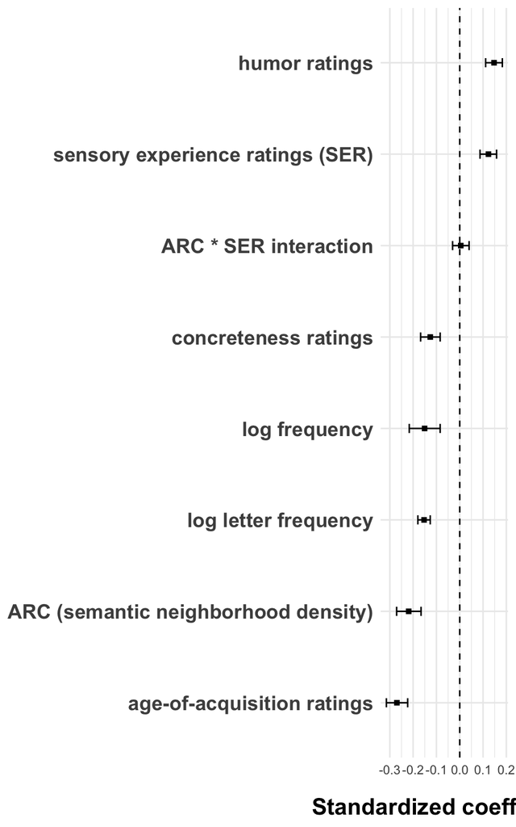

```r
# Setup the plot:

coef_p <- fixefs %>%
  ggplot(aes(x = reorder(variable, Estimate), y = Estimate,
             ymin = Q2.5, ymax = Q97.5))

# Add geoms:

coef_p <- coef_p +
  geom_point(shape = 15) +
  geom_hline(aes(yintercept = 0), linetype = 2) +
  geom_errorbar(width = 0.1)

# Add cosmetics:

coef_p <- coef_p +
  ylab('Standardized coefficient') +
  coord_flip() +
  theme_minimal() +
  theme(axis.title.y = element_blank(),
        axis.title.x = element_text(margin = margin(t = 15, b = 0,
                                                    r = 0, l = 0),
                                    face = 'bold',
                                    size = 16),
        axis.text.y = element_text(face = 'bold', size = 14))

# Show plot:

coef_p
```

```r
# Save:

ggsave(plot = coef_p, filename = '../figures/main_coefficients.pdf',
       width = 9, height = 5.5)
```

Create the predictions for POS categories:

```r
# Extract posteriors

POS_posts <- posterior_samples(all_mdl)
# Add posterior samples of the respective coefficients

functions <- POS_posts$b_Intercept
adjs <- POS_posts$b_Intercept + POS_posts$b_POS_simpleAdjective
advbs <- POS_posts$b_Intercept + POS_posts$b_POS_simpleAdverb
interj <- POS_posts$b_Intercept + POS_posts$b_POS_simpleInterjection
nouns <- POS_posts$b_Intercept + POS_posts$b_POS_simpleNoun
verbs <- POS_posts$b_Intercept + POS_posts$b_POS_simpleVerb

# Create tibble:

preds <- tibble(POS = c('Function',
                        'Adverb',
                        'Noun',
                        'Adjective',
                        'Verb',
                        'Interjection'),
                Estimate = c(mean(functions),
                             mean(advbs),
                             mean(nouns),
                             mean(adjs),
                             mean(verbs),
                             mean(interj)),
                Q2.5 = c(quantile(functions, 0.025),
                         quantile(advbs, 0.025),
                         quantile(nouns, 0.025),
                         quantile(adjs, 0.025),
                         quantile(verbs, 0.025),
                         quantile(interj, 0.025)),
                Q97.5 = c(quantile(functions, 0.975),
                          quantile(advbs, 0.975),
                          quantile(nouns, 0.975),
                          quantile(adjs, 0.975),
                          quantile(verbs, 0.975),
                          quantile(interj, 0.975)))

# Show:

preds
```

```
## # A tibble: 6 × 4
##   POS          Estimate  Q2.5 Q97.5
##   <chr>           <dbl> <dbl> <dbl>
## 1 Function         4.18  3.92  4.43
## 2 Adverb           4.13  3.64  4.63
## 3 Noun             3.91  3.86  3.96
## 4 Adjective        4.12  4.00  4.25
## 5 Verb             4.46  4.38  4.54
## 6 Interjection     4.36  3.83  4.86
```

Make a prediction plot of this:

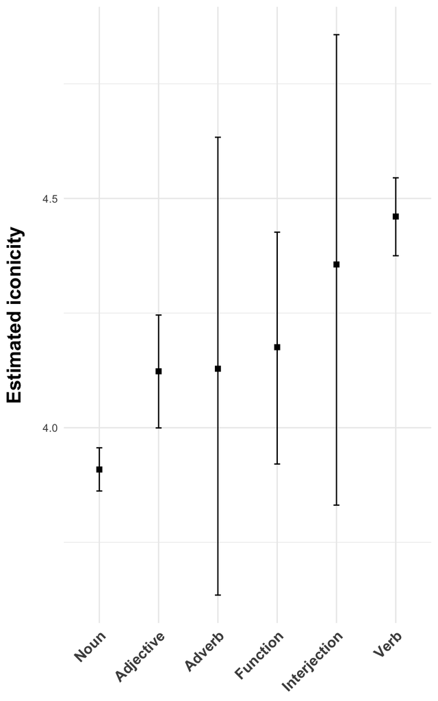

```r
# Setup the plot:

POS_p <- preds %>%
  ggplot(aes(x = reorder(POS, Estimate), y = Estimate,
             ymin = Q2.5, ymax = Q97.5))

# Add geoms:

POS_p <- POS_p +
  geom_point(shape = 15, size = 2) +
  geom_errorbar(width = 0.1)

# Add cosmetics:

POS_p <- POS_p +
  ylab('Estimated iconicity') +
  theme_minimal() +
  theme(axis.title.x = element_blank(),
        axis.text.x = element_text(face = 'bold',
                                   size = 12, angle = 45, hjust = 1),
        axis.title.y = element_text(margin = margin(t = 0, b = 0,
                                                    r = 15, l = 0),
                                    face = 'bold', size = 16))

# Show plot:

POS_p
```

```r
# Save:

ggsave(plot = POS_p, filename = '../figures/POS_preds.pdf',
       width = 7, height = 7)
```

This completes this analysis.